# Exploration of a Series of Red Wines

### Citric Acid vs Fixed Acidity and pH

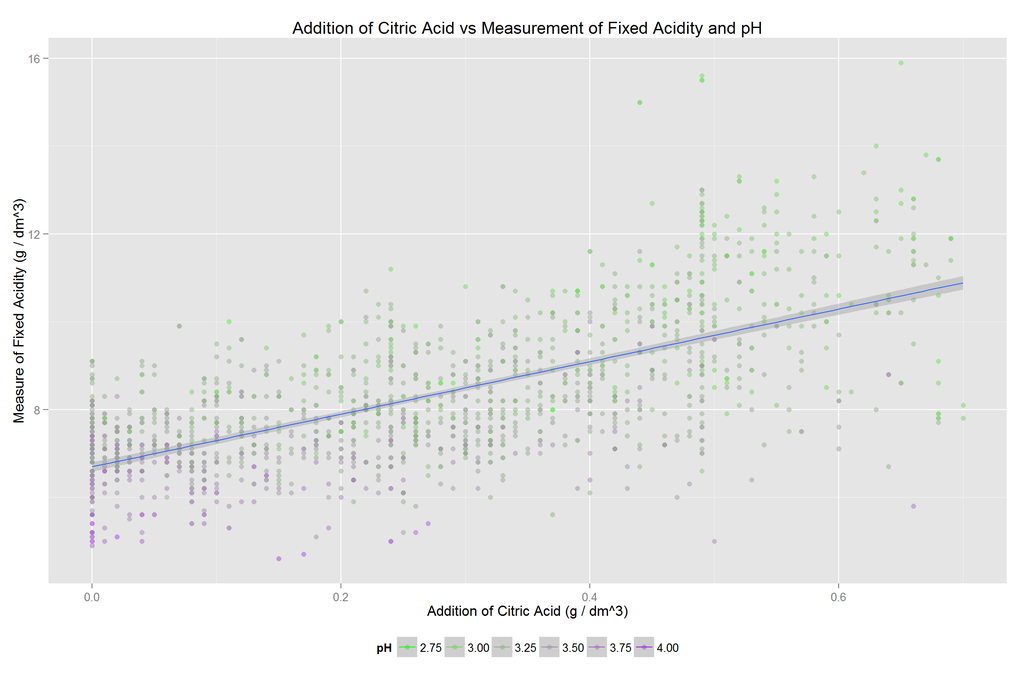

With a mind on the chemistry of the wine, I also expected there to be a direct relationship between the Addition of Citric Acid to the wine and the measured levels of Fixed Acidity. Sure enough, there is a very strong positive correlation between these two variables with a correlation coefficient of 0.672. The above chart also demonstrates this positive relationship.

## Reflection

This data set contains some very interesting and varied information regarding the red wine produced from the Portuguese “Vinho Verde” wine varietal. I initially set out to try and find some key factors that would help me to estimate the quality of a bottle of red wine given some background information. After going through the data, however, I think that the data contained herein would be of little use to me with the bulk of the wines in this data set being ranked as either a 5 or a 6, it is hard to determine strong trends that hold up across the full range of quality.

My initial expectations for the data ended up being invalid after a brief analysis. I had initially believed the concentration of residual sugars and the pH of a wine to have a more substantial effect on the quality of wine. However, after considering these two variables against the quality rankings of wine, it was determined that they have little to no influence on the quality. Instead, I found that the addatives, citric acid and sulphates, included in the wine making process for flavor and preservation enhancement had surprisingly positive effects on the wine.

Another interesting effect I discovered was the effect of residual sugars on the density of the wine. It turns out that a higher concentration of residual sugars left over from the fermentation process can raise the density of the wine.

Overall, I think this is a decent data set, but for future analyses I would look for more observations, preferably with more observations having quality rankings outside of the mid-ranged wines, both higher and lower quality. Some of the data did seem irrelavent in my explorations, such as the free and total sulfur dioxide measurements, and would not be required in a future edition of the data set.